# Regression model for Bike-Sharing dataset

### Model 8 - Removing additional variables with high p-value

```python
cols = ['yr', 'casual', 'workingday', 'mnth_feb',
       'mnth_jan', 'mnth_mar','weathersit_moderate']

build_model(cols)
get_vif(cols)
```

```
                            OLS Regression Results
==============================================================================
Dep. Variable:                    cnt   R-squared:                       0.862
Model:                            OLS   Adj. R-squared:                  0.860
Method:                 Least Squares   F-statistic:                     447.4
Date:                Wed, 14 Feb 2024   Prob (F-statistic):          3.63e-211
Time:                        21:22:45   Log-Likelihood:                -4082.1
No. Observations:                 510   AIC:                             8180.
Df Residuals:                     502   BIC:                             8214.
Df Model:                           7
Covariance Type:            nonrobust
=======================================================================================
                          coef    std err          t      P>|t|      [0.025      0.975]
---------------------------------------------------------------------------------------
const                1222.1644    117.500     10.401      0.000     991.311    1453.018
yr                   1544.4022     69.209     22.315      0.000    1408.426    1680.378
casual                  1.9633      0.069     28.500      0.000       1.828       2.099
workingday           1763.6583     86.191     20.462      0.000    1594.319    1932.997
mnth_feb             -966.6388    140.495     -6.880      0.000   -1242.670    -690.608
mnth_jan            -1231.5131    127.829     -9.634      0.000   -1482.658    -980.368
mnth_mar             -892.5998    111.044     -8.038      0.000   -1110.769    -674.431
weathersit_moderate  -284.4001     69.070     -4.118      0.000    -420.103    -148.698
==============================================================================
Omnibus:                      134.142   Durbin-Watson:                   2.033
Prob(Omnibus):                  0.000   Jarque-Bera (JB):              460.722
Skew:                          -1.189   Prob(JB):                    9.03e-101
Kurtosis:                       7.003   Cond. No.                     5.96e+03
==============================================================================

Notes:
[1] Standard Errors assume that the covariance matrix of the errors is correctly specified.
[2] The condition number is large, 5.96e+03. This might indicate that there are
strong multicollinearity or other numerical problems.
              Features   VIF
0                   yr  2.33
1               casual  1.92
2           workingday  1.88
6  weathersit_moderate  1.43
4             mnth_jan  1.12
5             mnth_mar  1.10
3             mnth_feb  1.07
```

**Observation**  
p-values and VIF are within the range. Hence, we will use this model.

### We will build a final model using the last set of features

```python
#Build a model with all columns to select features automatically
def build_model_sk(X,y):
    lr1 = LinearRegression()
    lr1.fit(X,y)
    return lr1
```

```python
#Let us build the finalmodel using sklearn
lr = build_model_sk(X_train[cols],y_train)
print(lr.intercept_,lr.coef_)
```

```
1222.1643523418716 [ 1544.40221192     1.96333765  1763.65834288  -966.6387691
 -1231.51309511  -892.59982745  -284.40014021]
```

**Next Step** - We will perform prediction on train set, and perform Residual analysis.

### Residual Analysis

```python
y_train_pred = lr.predict(X_train[cols])
```

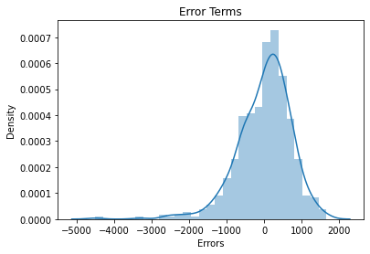

```python
sns.distplot(y_train-y_train_pred)
plt.title('Error Terms')
plt.xlabel('Errors')
plt.show()
```

**Observation** - We see that the residuals are centered around zero, which confirms one of the assumptions of linrear regression.

**Next Step** - We will check R-square for predictions on train set.

### R-Squared value for train predictions

```python
#Print R-squared Value
r2_score(y_train,y_train_pred)
```

```
0.8618401205169273
```

**Next Step** - We will predict values on test dataset.

### Prediction on test dataset

```python
df_test_copy = df_test
```

```python
### Dividing into X and Y sets for the model building

y_test = df_test.pop('cnt')
X_test = df_test
```

```python
#Scale variables in X_test
num_vars = ['temp','atemp','hum','windspeed']

#Test data to be transformed only, no fitting
X_test[num_vars] = scaler.transform(X_test[num_vars])
```

```python
cols = ['yr', 'casual', 'workingday', 'mnth_feb',
       'mnth_jan', 'mnth_mar','weathersit_moderate']

#Predicting test data values
y_test_pred = lr.predict(X_test[cols])
```

### R-Squared value for test predictions

```python
# Find out the R squared value between test and predicted test data sets.
r2_score(y_test,y_test_pred)
```

```
0.8018879251833619
```

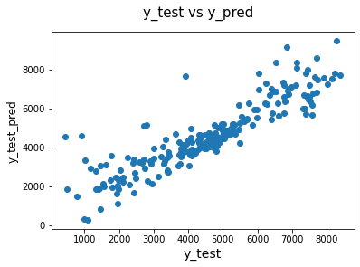

```python
fig = plt.figure()
plt.scatter(y_test, y_test_pred)
fig.suptitle('y_test vs y_pred', fontsize = 15)
plt.xlabel('y_test', fontsize = 14)
plt.ylabel('y_test_pred', fontsize = 12)
```